# SeqMonk Vistory Report

Project Loaded

Loaded D:\files_too_big_to_sync\pluripotency_exit_EB.smk

DataSet Added

lane2_EB_TET_KO_2.1_TACAGGAT_L002_3536STDY7824965_R1_val_1_GRCm38_hisat2.bam /bi/seqfac/seqfac/190324_Tim_Globus/Aligned/Project_Sanger/Sample_lane2/lane2_EB_TET_KO_2.1_TACAGGAT_L002_3536STDY7824965_R1_val_1_GRCm38_hisat2.bam Library type Paired End Dedup=No MAPQ>=20 Primary alignments only. Treat as RNA-Seq dataPaired distance cutoff = 1000

DataSet Added

lane2_EB_TET_KO_2.2_TCCTCAAT_L002_3536STDY7824966_R1_val_1_GRCm38_hisat2.bam /bi/seqfac/seqfac/190324_Tim_Globus/Aligned/Project_Sanger/Sample_lane2/lane2_EB_TET_KO_2.2_TCCTCAAT_L002_3536STDY7824966_R1_val_1_GRCm38_hisat2.bam Library type Paired End Dedup=No MAPQ>=20 Primary alignments only. Treat as RNA-Seq dataPaired distance cutoff = 1000

DataSet Added

lane2_EB_TET_KO_4.1_TGTGGTTG_L002_3536STDY7824968_R1_val_1_GRCm38_hisat2.bam /bi/seqfac/seqfac/190324_Tim_Globus/Aligned/Project_Sanger/Sample_lane2/lane2_EB_TET_KO_4.1_TGTGGTTG_L002_3536STDY7824968_R1_val_1_GRCm38_hisat2.bam Library type Paired End Dedup=No MAPQ>=20 Primary alignments only. Treat as RNA-Seq dataPaired distance cutoff = 1000

DataSet Added

lane2_EB_TET_KO_4.2_TAGTCTTG_L002_3536STDY7824969_R1_val_1_GRCm38_hisat2.bam /bi/seqfac/seqfac/190324_Tim_Globus/Aligned/Project_Sanger/Sample_lane2/lane2_EB_TET_KO_4.2_TAGTCTTG_L002_3536STDY7824969_R1_val_1_GRCm38_hisat2.bam Library type Paired End Dedup=No MAPQ>=20 Primary alignments only. Treat as RNA-Seq dataPaired distance cutoff = 1000

DataSet Added

lane2_EB_TET_KO_4.3_TTCCATTG_L002_3536STDY7824970_R1_val_1_GRCm38_hisat2.bam /bi/seqfac/seqfac/190324_Tim_Globus/Aligned/Project_Sanger/Sample_lane2/lane2_EB_TET_KO_4.3_TTCCATTG_L002_3536STDY7824970_R1_val_1_GRCm38_hisat2.bam Library type Paired End Dedup=No MAPQ>=20 Primary alignments only. Treat as RNA-Seq dataPaired distance cutoff = 1000

DataSet Added

lane2_EB_TET_KO_6.1_TCGAAGTG_L002_3536STDY7824971_R1_val_1_GRCm38_hisat2.bam /bi/seqfac/seqfac/190324_Tim_Globus/Aligned/Project_Sanger/Sample_lane2/lane2_EB_TET_KO_6.1_TCGAAGTG_L002_3536STDY7824971_R1_val_1_GRCm38_hisat2.bam Library type Paired End Dedup=No MAPQ>=20 Primary alignments only. Treat as RNA-Seq dataPaired distance cutoff = 1000

DataSet Added

lane2_EB_TET_KO_6.2_TAACGCTG_L002_3536STDY7824972_R1_val_1_GRCm38_hisat2.bam /bi/seqfac/seqfac/190324_Tim_Globus/Aligned/Project_Sanger/Sample_lane2/lane2_EB_TET_KO_6.2_TAACGCTG_L002_3536STDY7824972_R1_val_1_GRCm38_hisat2.bam Library type Paired End Dedup=No MAPQ>=20 Primary alignments only. Treat as RNA-Seq dataPaired distance cutoff = 1000

DataSet Added

lane2_EB_TET_KO_6.3_TTGGTATG_L002_3536STDY7824973_R1_val_1_GRCm38_hisat2.bam /bi/seqfac/seqfac/190324_Tim_Globus/Aligned/Project_Sanger/Sample_lane2/lane2_EB_TET_KO_6.3_TTGGTATG_L002_3536STDY7824973_R1_val_1_GRCm38_hisat2.bam Library type Paired End Dedup=No MAPQ>=20 Primary alignments only. Treat as RNA-Seq dataPaired distance cutoff = 1000

DataSet Added

lane2_EB_TET_WT_2.1_TAGCTTGT_L002_3536STDY7824947_R1_val_1_GRCm38_hisat2.bam /bi/seqfac/seqfac/190324_Tim_Globus/Aligned/Project_Sanger/Sample_lane2/lane2_EB_TET_WT_2.1_TAGCTTGT_L002_3536STDY7824947_R1_val_1_GRCm38_hisat2.bam Library type Paired End Dedup=No MAPQ>=20 Primary alignments only. Treat as RNA-Seq dataPaired distance cutoff = 1000

DataSet Added

lane2_EB_TET_WT_2.2_GGCTACAG_L002_3536STDY7824948_R1_val_1_GRCm38_hisat2.bam /bi/seqfac/seqfac/190324_Tim_Globus/Aligned/Project_Sanger/Sample_lane2/lane2_EB_TET_WT_2.2_GGCTACAG_L002_3536STDY7824948_R1_val_1_GRCm38_hisat2.bam Library type Paired End Dedup=No MAPQ>=20 Primary alignments only. Treat as RNA-Seq dataPaired distance cutoff = 1000

DataSet Added

lane2_EB_TET_WT_2.3_CTTGTACT_L002_3536STDY7824949_R1_val_1_GRCm38_hisat2.bam /bi/seqfac/seqfac/190324_Tim_Globus/Aligned/Project_Sanger/Sample_lane2/lane2_EB_TET_WT_2.3_CTTGTACT_L002_3536STDY7824949_R1_val_1_GRCm38_hisat2.bam Library type Paired End Dedup=No MAPQ>=20 Primary alignments only. Treat as RNA-Seq dataPaired distance cutoff = 1000

DataSet Added

lane2_EB_TET_WT_4.1_TGGTTGTT_L002_3536STDY7824950_R1_val_1_GRCm38_hisat2.bam /bi/seqfac/seqfac/190324_Tim_Globus/Aligned/Project_Sanger/Sample_lane2/lane2_EB_TET_WT_4.1_TGGTTGTT_L002_3536STDY7824950_R1_val_1_GRCm38_hisat2.bam Library type Paired End Dedup=No MAPQ>=20 Primary alignments only. Treat as RNA-Seq dataPaired distance cutoff = 1000

DataSet Added

lane2_EB_TET_WT_4.2_TCTCGGTT_L002_3536STDY7824951_R1_val_1_GRCm38_hisat2.bam /bi/seqfac/seqfac/190324_Tim_Globus/Aligned/Project_Sanger/Sample_lane2/lane2_EB_TET_WT_4.2_TCTCGGTT_L002_3536STDY7824951_R1_val_1_GRCm38_hisat2.bam Library type Paired End Dedup=No MAPQ>=20 Primary alignments only. Treat as RNA-Seq dataPaired distance cutoff = 1000

DataSet Added

lane2_EB_TET_WT_4.3_TAAGCGTT_L002_3536STDY7824952_R1_val_1_GRCm38_hisat2.bam /bi/seqfac/seqfac/190324_Tim_Globus/Aligned/Project_Sanger/Sample_lane2/lane2_EB_TET_WT_4.3_TAAGCGTT_L002_3536STDY7824952_R1_val_1_GRCm38_hisat2.bam Library type Paired End Dedup=No MAPQ>=20 Primary alignments only. Treat as RNA-Seq dataPaired distance cutoff = 1000

DataSet Added

lane2_EB_TET_WT_6.1_TCCGTCTT_L002_3536STDY7824953_R1_val_1_GRCm38_hisat2.bam /bi/seqfac/seqfac/190324_Tim_Globus/Aligned/Project_Sanger/Sample_lane2/lane2_EB_TET_WT_6.1_TCCGTCTT_L002_3536STDY7824953_R1_val_1_GRCm38_hisat2.bam Library type Paired End Dedup=No MAPQ>=20 Primary alignments only. Treat as RNA-Seq dataPaired distance cutoff = 1000

DataSet Added

lane2_EB_TET_WT_6.2_TGTACCTT_L002_3536STDY7824954_R1_val_1_GRCm38_hisat2.bam /bi/seqfac/seqfac/190324_Tim_Globus/Aligned/Project_Sanger/Sample_lane2/lane2_EB_TET_WT_6.2_TGTACCTT_L002_3536STDY7824954_R1_val_1_GRCm38_hisat2.bam Library type Paired End Dedup=No MAPQ>=20 Primary alignments only. Treat as RNA-Seq dataPaired distance cutoff = 1000

DataSet Added

lane2_EB_TET_WT_6.3_TTCTGTGT_L002_3536STDY7824955_R1_val_1_GRCm38_hisat2.bam /bi/seqfac/seqfac/190324_Tim_Globus/Aligned/Project_Sanger/Sample_lane2/lane2_EB_TET_WT_6.3_TTCTGTGT_L002_3536STDY7824955_R1_val_1_GRCm38_hisat2.bam Library type Paired End Dedup=No MAPQ>=20 Primary alignments only. Treat as RNA-Seq dataPaired distance cutoff = 1000

DataSet Added

lane2_mESC_TET_KO_2iL_0.1_TCTGCTGT_L002_3536STDY7824956_R1_val_1_GRCm38_hisat2.bam /bi/seqfac/seqfac/190324_Tim_Globus/Aligned/Project_Sanger/Sample_lane2/lane2_mESC_TET_KO_2iL_0.1_TCTGCTGT_L002_3536STDY7824956_R1_val_1_GRCm38_hisat2.bam Library type Paired End Dedup=No MAPQ>=20 Primary alignments only. Treat as RNA-Seq dataPaired distance cutoff = 1000

DataSet Added

lane2_mESC_TET_KO_2iL_0.2_TTGGAGGT_L002_3536STDY7824957_R1_val_1_GRCm38_hisat2.bam /bi/seqfac/seqfac/190324_Tim_Globus/Aligned/Project_Sanger/Sample_lane2/lane2_mESC_TET_KO_2iL_0.2_TTGGAGGT_L002_3536STDY7824957_R1_val_1_GRCm38_hisat2.bam Library type Paired End Dedup=No MAPQ>=20 Primary alignments only. Treat as RNA-Seq dataPaired distance cutoff = 1000

DataSet Added

lane2_mESC_TET_KO_2iL_0.3_TCGAGCGT_L002_3536STDY7824958_R1_val_1_GRCm38_hisat2.bam /bi/seqfac/seqfac/190324_Tim_Globus/Aligned/Project_Sanger/Sample_lane2/lane2_mESC_TET_KO_2iL_0.3_TCGAGCGT_L002_3536STDY7824958_R1_val_1_GRCm38_hisat2.bam Library type Paired End Dedup=No MAPQ>=20 Primary alignments only. Treat as RNA-Seq dataPaired distance cutoff = 1000

DataSet Added

lane2_mESC_TET_WT_2iL_0.1_ATCACGTT_L002_3536STDY7824938_R1_val_1_GRCm38_hisat2.bam /bi/seqfac/seqfac/190324_Tim_Globus/Aligned/Project_Sanger/Sample_lane2/lane2_mESC_TET_WT_2iL_0.1_ATCACGTT_L002_3536STDY7824938_R1_val_1_GRCm38_hisat2.bam Library type Paired End Dedup=No MAPQ>=20 Primary alignments only. Treat as RNA-Seq dataPaired distance cutoff = 1000

DataSet Added

lane2_mESC_TET_WT_2iL_0.2_CGATGTTT_L002_3536STDY7824939_R1_val_1_GRCm38_hisat2.bam /bi/seqfac/seqfac/190324_Tim_Globus/Aligned/Project_Sanger/Sample_lane2/lane2_mESC_TET_WT_2iL_0.2_CGATGTTT_L002_3536STDY7824939_R1_val_1_GRCm38_hisat2.bam Library type Paired End Dedup=No MAPQ>=20 Primary alignments only. Treat as RNA-Seq dataPaired distance cutoff = 1000

DataSet Added

lane2_mESC_TET_WT_2iL_0.3_TTAGGCAT_L002_3536STDY7824940_R1_val_1_GRCm38_hisat2.bam /bi/seqfac/seqfac/190324_Tim_Globus/Aligned/Project_Sanger/Sample_lane2/lane2_mESC_TET_WT_2iL_0.3_TTAGGCAT_L002_3536STDY7824940_R1_val_1_GRCm38_hisat2.bam Library type Paired End Dedup=No MAPQ>=20 Primary alignments only. Treat as RNA-Seq dataPaired distance cutoff = 1000

Data Set Renamed

lane2_EB_TET_KO_2.1_TACAGGAT_L002_3536STDY7824965_R1_val_1_GRCm38_hisat2.bam changed to EB_TET_KO_2.1_TACAGGAT_L002_3536STDY7824965_R1_val_1_GRCm38_hisat2.bam

Data Set Renamed

lane2_EB_TET_KO_2.2_TCCTCAAT_L002_3536STDY7824966_R1_val_1_GRCm38_hisat2.bam changed to EB_TET_KO_2.2_TCCTCAAT_L002_3536STDY7824966_R1_val_1_GRCm38_hisat2.bam

Data Set Renamed

lane2_EB_TET_KO_4.1_TGTGGTTG_L002_3536STDY7824968_R1_val_1_GRCm38_hisat2.bam changed to EB_TET_KO_4.1_TGTGGTTG_L002_3536STDY7824968_R1_val_1_GRCm38_hisat2.bam

Data Set Renamed

lane2_EB_TET_KO_4.2_TAGTCTTG_L002_3536STDY7824969_R1_val_1_GRCm38_hisat2.bam changed to EB_TET_KO_4.2_TAGTCTTG_L002_3536STDY7824969_R1_val_1_GRCm38_hisat2.bam

Data Set Renamed

lane2_EB_TET_KO_4.3_TTCCATTG_L002_3536STDY7824970_R1_val_1_GRCm38_hisat2.bam changed to EB_TET_KO_4.3_TTCCATTG_L002_3536STDY7824970_R1_val_1_GRCm38_hisat2.bam

Data Set Renamed

lane2_EB_TET_KO_6.1_TCGAAGTG_L002_3536STDY7824971_R1_val_1_GRCm38_hisat2.bam changed to EB_TET_KO_6.1_TCGAAGTG_L002_3536STDY7824971_R1_val_1_GRCm38_hisat2.bam

Data Set Renamed

lane2_EB_TET_KO_6.2_TAACGCTG_L002_3536STDY7824972_R1_val_1_GRCm38_hisat2.bam changed to EB_TET_KO_6.2_TAACGCTG_L002_3536STDY7824972_R1_val_1_GRCm38_hisat2.bam

Data Set Renamed

lane2_EB_TET_KO_6.3_TTGGTATG_L002_3536STDY7824973_R1_val_1_GRCm38_hisat2.bam changed to EB_TET_KO_6.3_TTGGTATG_L002_3536STDY7824973_R1_val_1_GRCm38_hisat2.bam

Data Set Renamed

lane2_EB_TET_WT_2.1_TAGCTTGT_L002_3536STDY7824947_R1_val_1_GRCm38_hisat2.bam changed to EB_TET_WT_2.1_TAGCTTGT_L002_3536STDY7824947_R1_val_1_GRCm38_hisat2.bam

Data Set Renamed

lane2_EB_TET_WT_2.2_GGCTACAG_L002_3536STDY7824948_R1_val_1_GRCm38_hisat2.bam changed to EB_TET_WT_2.2_GGCTACAG_L002_3536STDY7824948_R1_val_1_GRCm38_hisat2.bam

Data Set Renamed

lane2_EB_TET_WT_2.3_CTTGTACT_L002_3536STDY7824949_R1_val_1_GRCm38_hisat2.bam changed to EB_TET_WT_2.3_CTTGTACT_L002_3536STDY7824949_R1_val_1_GRCm38_hisat2.bam

Data Set Renamed

lane2_EB_TET_WT_4.1_TGGTTGTT_L002_3536STDY7824950_R1_val_1_GRCm38_hisat2.bam changed to EB_TET_WT_4.1_TGGTTGTT_L002_3536STDY7824950_R1_val_1_GRCm38_hisat2.bam

Data Set Renamed

lane2_EB_TET_WT_4.2_TCTCGGTT_L002_3536STDY7824951_R1_val_1_GRCm38_hisat2.bam changed to EB_TET_WT_4.2_TCTCGGTT_L002_3536STDY7824951_R1_val_1_GRCm38_hisat2.bam

Data Set Renamed

lane2_EB_TET_WT_4.3_TAAGCGTT_L002_3536STDY7824952_R1_val_1_GRCm38_hisat2.bam changed to EB_TET_WT_4.3_TAAGCGTT_L002_3536STDY7824952_R1_val_1_GRCm38_hisat2.bam

Data Set Renamed

lane2_EB_TET_WT_6.1_TCCGTCTT_L002_3536STDY7824953_R1_val_1_GRCm38_hisat2.bam changed to EB_TET_WT_6.1_TCCGTCTT_L002_3536STDY7824953_R1_val_1_GRCm38_hisat2.bam

Data Set Renamed

lane2_EB_TET_WT_6.2_TGTACCTT_L002_3536STDY7824954_R1_val_1_GRCm38_hisat2.bam changed to EB_TET_WT_6.2_TGTACCTT_L002_3536STDY7824954_R1_val_1_GRCm38_hisat2.bam

Data Set Renamed

lane2_EB_TET_WT_6.3_TTCTGTGT_L002_3536STDY7824955_R1_val_1_GRCm38_hisat2.bam changed to EB_TET_WT_6.3_TTCTGTGT_L002_3536STDY7824955_R1_val_1_GRCm38_hisat2.bam

Data Set Renamed

lane2_mESC_TET_KO_2iL_0.1_TCTGCTGT_L002_3536STDY7824956_R1_val_1_GRCm38_hisat2.bam changed to mESC_TET_KO_2iL_0.1_TCTGCTGT_L002_3536STDY7824956_R1_val_1_GRCm38_hisat2.bam

Data Set Renamed

lane2_mESC_TET_KO_2iL_0.2_TTGGAGGT_L002_3536STDY7824957_R1_val_1_GRCm38_hisat2.bam changed to mESC_TET_KO_2iL_0.2_TTGGAGGT_L002_3536STDY7824957_R1_val_1_GRCm38_hisat2.bam

Data Set Renamed

lane2_mESC_TET_KO_2iL_0.3_TCGAGCGT_L002_3536STDY7824958_R1_val_1_GRCm38_hisat2.bam changed to mESC_TET_KO_2iL_0.3_TCGAGCGT_L002_3536STDY7824958_R1_val_1_GRCm38_hisat2.bam

Data Set Renamed

lane2_mESC_TET_WT_2iL_0.1_ATCACGTT_L002_3536STDY7824938_R1_val_1_GRCm38_hisat2.bam changed to mESC_TET_WT_2iL_0.1_ATCACGTT_L002_3536STDY7824938_R1_val_1_GRCm38_hisat2.bam

Data Set Renamed

lane2_mESC_TET_WT_2iL_0.2_CGATGTTT_L002_3536STDY7824939_R1_val_1_GRCm38_hisat2.bam changed to mESC_TET_WT_2iL_0.2_CGATGTTT_L002_3536STDY7824939_R1_val_1_GRCm38_hisat2.bam

Data Set Renamed

lane2_mESC_TET_WT_2iL_0.3_TTAGGCAT_L002_3536STDY7824940_R1_val_1_GRCm38_hisat2.bam changed to mESC_TET_WT_2iL_0.3_TTAGGCAT_L002_3536STDY7824940_R1_val_1_GRCm38_hisat2.bam

Data Set Renamed

EB_TET_KO_2.1_TACAGGAT_L002_3536STDY7824965_R1_val_1_GRCm38_hisat2.bam changed to EB_TET_KO_2.1_TACAGGAT_L002_3536STDY7824965

Data Set Renamed

EB_TET_KO_2.2_TCCTCAAT_L002_3536STDY7824966_R1_val_1_GRCm38_hisat2.bam changed to EB_TET_KO_2.2_TCCTCAAT_L002_3536STDY7824966

Data Set Renamed

EB_TET_KO_4.1_TGTGGTTG_L002_3536STDY7824968_R1_val_1_GRCm38_hisat2.bam changed to EB_TET_KO_4.1_TGTGGTTG_L002_3536STDY7824968

Data Set Renamed

EB_TET_KO_4.2_TAGTCTTG_L002_3536STDY7824969_R1_val_1_GRCm38_hisat2.bam changed to EB_TET_KO_4.2_TAGTCTTG_L002_3536STDY7824969

Data Set Renamed

EB_TET_KO_4.3_TTCCATTG_L002_3536STDY7824970_R1_val_1_GRCm38_hisat2.bam changed to EB_TET_KO_4.3_TTCCATTG_L002_3536STDY7824970

Data Set Renamed

EB_TET_KO_6.1_TCGAAGTG_L002_3536STDY7824971_R1_val_1_GRCm38_hisat2.bam changed to EB_TET_KO_6.1_TCGAAGTG_L002_3536STDY7824971

Data Set Renamed

EB_TET_KO_6.2_TAACGCTG_L002_3536STDY7824972_R1_val_1_GRCm38_hisat2.bam changed to EB_TET_KO_6.2_TAACGCTG_L002_3536STDY7824972

Data Set Renamed

EB_TET_KO_6.3_TTGGTATG_L002_3536STDY7824973_R1_val_1_GRCm38_hisat2.bam changed to EB_TET_KO_6.3_TTGGTATG_L002_3536STDY7824973

Data Set Renamed

EB_TET_WT_2.1_TAGCTTGT_L002_3536STDY7824947_R1_val_1_GRCm38_hisat2.bam changed to EB_TET_WT_2.1_TAGCTTGT_L002_3536STDY7824947

Data Set Renamed

EB_TET_WT_2.2_GGCTACAG_L002_3536STDY7824948_R1_val_1_GRCm38_hisat2.bam changed to EB_TET_WT_2.2_GGCTACAG_L002_3536STDY7824948

Data Set Renamed

EB_TET_WT_2.3_CTTGTACT_L002_3536STDY7824949_R1_val_1_GRCm38_hisat2.bam changed to EB_TET_WT_2.3_CTTGTACT_L002_3536STDY7824949

Data Set Renamed

EB_TET_WT_4.1_TGGTTGTT_L002_3536STDY7824950_R1_val_1_GRCm38_hisat2.bam changed to EB_TET_WT_4.1_TGGTTGTT_L002_3536STDY7824950

Data Set Renamed

EB_TET_WT_4.2_TCTCGGTT_L002_3536STDY7824951_R1_val_1_GRCm38_hisat2.bam changed to EB_TET_WT_4.2_TCTCGGTT_L002_3536STDY7824951

Data Set Renamed

EB_TET_WT_4.3_TAAGCGTT_L002_3536STDY7824952_R1_val_1_GRCm38_hisat2.bam changed to EB_TET_WT_4.3_TAAGCGTT_L002_3536STDY7824952

Data Set Renamed

EB_TET_WT_6.1_TCCGTCTT_L002_3536STDY7824953_R1_val_1_GRCm38_hisat2.bam changed to EB_TET_WT_6.1_TCCGTCTT_L002_3536STDY7824953

Data Set Renamed

EB_TET_WT_6.2_TGTACCTT_L002_3536STDY7824954_R1_val_1_GRCm38_hisat2.bam changed to EB_TET_WT_6.2_TGTACCTT_L002_3536STDY7824954

Data Set Renamed

EB_TET_WT_6.3_TTCTGTGT_L002_3536STDY7824955_R1_val_1_GRCm38_hisat2.bam changed to EB_TET_WT_6.3_TTCTGTGT_L002_3536STDY7824955

Data Set Renamed

mESC_TET_KO_2iL_0.1_TCTGCTGT_L002_3536STDY7824956_R1_val_1_GRCm38_hisat2.bam changed to mESC_TET_KO_2iL_0.1_TCTGCTGT_L002_3536STDY7824956

Data Set Renamed

mESC_TET_KO_2iL_0.2_TTGGAGGT_L002_3536STDY7824957_R1_val_1_GRCm38_hisat2.bam changed to mESC_TET_KO_2iL_0.2_TTGGAGGT_L002_3536STDY7824957

Data Set Renamed

mESC_TET_KO_2iL_0.3_TCGAGCGT_L002_3536STDY7824958_R1_val_1_GRCm38_hisat2.bam changed to mESC_TET_KO_2iL_0.3_TCGAGCGT_L002_3536STDY7824958

Data Set Renamed

mESC_TET_WT_2iL_0.1_ATCACGTT_L002_3536STDY7824938_R1_val_1_GRCm38_hisat2.bam changed to mESC_TET_WT_2iL_0.1_ATCACGTT_L002_3536STDY7824938

Data Set Renamed

mESC_TET_WT_2iL_0.2_CGATGTTT_L002_3536STDY7824939_R1_val_1_GRCm38_hisat2.bam changed to mESC_TET_WT_2iL_0.2_CGATGTTT_L002_3536STDY7824939

Data Set Renamed

mESC_TET_WT_2iL_0.3_TTAGGCAT_L002_3536STDY7824940_R1_val_1_GRCm38_hisat2.bam changed to mESC_TET_WT_2iL_0.3_TTAGGCAT_L002_3536STDY7824940

Data Set Renamed

EB_TET_KO_2.1_TACAGGAT_L002_3536STDY7824965 changed to EB_TET_KO_2.1

Data Set Renamed

EB_TET_KO_2.2_TCCTCAAT_L002_3536STDY7824966 changed to EB_TET_KO_2.2

Data Set Renamed

EB_TET_KO_4.1_TGTGGTTG_L002_3536STDY7824968 changed to EB_TET_KO_4.1

Data Set Renamed

EB_TET_KO_4.2_TAGTCTTG_L002_3536STDY7824969 changed to EB_TET_KO_4.2

Data Set Renamed

EB_TET_KO_4.3_TTCCATTG_L002_3536STDY7824970 changed to EB_TET_KO_4.3

Data Set Renamed

EB_TET_KO_6.1_TCGAAGTG_L002_3536STDY7824971 changed to EB_TET_KO_6.1

Data Set Renamed

EB_TET_KO_6.2_TAACGCTG_L002_3536STDY7824972 changed to EB_TET_KO_6.2

Data Set Renamed

EB_TET_KO_6.3_TTGGTATG_L002_3536STDY7824973 changed to EB_TET_KO_6.3

Data Set Renamed

EB_TET_WT_2.1_TAGCTTGT_L002_3536STDY7824947 changed to EB_TET_WT_2.1

Data Set Renamed

EB_TET_WT_2.2_GGCTACAG_L002_3536STDY7824948 changed to EB_TET_WT_2.2

Data Set Renamed

EB_TET_WT_2.3_CTTGTACT_L002_3536STDY7824949 changed to EB_TET_WT_2.3

Data Set Renamed

EB_TET_WT_4.1_TGGTTGTT_L002_3536STDY7824950 changed to EB_TET_WT_4.1

Data Set Renamed

EB_TET_WT_4.2_TCTCGGTT_L002_3536STDY7824951 changed to EB_TET_WT_4.2

Data Set Renamed

EB_TET_WT_4.3_TAAGCGTT_L002_3536STDY7824952 changed to EB_TET_WT_4.3

Data Set Renamed

EB_TET_WT_6.1_TCCGTCTT_L002_3536STDY7824953 changed to EB_TET_WT_6.1

Data Set Renamed

EB_TET_WT_6.2_TGTACCTT_L002_3536STDY7824954 changed to EB_TET_WT_6.2

Data Set Renamed

EB_TET_WT_6.3_TTCTGTGT_L002_3536STDY7824955 changed to EB_TET_WT_6.3

Data Set Renamed

mESC_TET_KO_2iL_0.1_TCTGCTGT_L002_3536STDY7824956 changed to mESC_TET_KO_2iL_0.1

Data Set Renamed

mESC_TET_KO_2iL_0.2_TTGGAGGT_L002_3536STDY7824957 changed to mESC_TET_KO_2iL_0.2

Data Set Renamed

mESC_TET_KO_2iL_0.3_TCGAGCGT_L002_3536STDY7824958 changed to mESC_TET_KO_2iL_0.3

Data Set Renamed

mESC_TET_WT_2iL_0.1_ATCACGTT_L002_3536STDY7824938 changed to mESC_TET_WT_2iL_0.1

Data Set Renamed

mESC_TET_WT_2iL_0.2_CGATGTTT_L002_3536STDY7824939 changed to mESC_TET_WT_2iL_0.2

Data Set Renamed

mESC_TET_WT_2iL_0.3_TTAGGCAT_L002_3536STDY7824940 changed to mESC_TET_WT_2iL_0.3

## Project Summary

### Basic Project Info

| Parameter | Value |
| --- | --- |
| Project Name | pluripotency_exit_EB.smk |
| Vistory Name | [Not saved yet] |
| Genome | Mus musculus GRCm38_v95 |
| SeqMonk Version | 1.45.4 |

### Data Sets

| Name | File Name | Reads | Import Options |
| --- | --- | --- | --- |
| EB_TET_KO_2.1 | /bi/seqfac/seqfac/190324_Tim_Globus/Aligned/Project_Sanger/Sample_lane2/lane2_EB_TET_KO_2.1_TACAGGAT_L002_3536STDY7824965_R1_val_1_GRCm38_hisat2.bam | 13033904 | Library type Paired End Dedup=No MAPQ>=20 Primary alignments only. Treat as RNA-Seq dataPaired distance cutoff = 1000 |
| EB_TET_KO_2.2 | /bi/seqfac/seqfac/190324_Tim_Globus/Aligned/Project_Sanger/Sample_lane2/lane2_EB_TET_KO_2.2_TCCTCAAT_L002_3536STDY7824966_R1_val_1_GRCm38_hisat2.bam | 15087470 | Library type Paired End Dedup=No MAPQ>=20 Primary alignments only. Treat as RNA-Seq dataPaired distance cutoff = 1000 |
| EB_TET_KO_4.1 | /bi/seqfac/seqfac/190324_Tim_Globus/Aligned/Project_Sanger/Sample_lane2/lane2_EB_TET_KO_4.1_TGTGGTTG_L002_3536STDY7824968_R1_val_1_GRCm38_hisat2.bam | 14716633 | Library type Paired End Dedup=No MAPQ>=20 Primary alignments only. Treat as RNA-Seq dataPaired distance cutoff = 1000 |
| EB_TET_KO_4.2 | /bi/seqfac/seqfac/190324_Tim_Globus/Aligned/Project_Sanger/Sample_lane2/lane2_EB_TET_KO_4.2_TAGTCTTG_L002_3536STDY7824969_R1_val_1_GRCm38_hisat2.bam | 15264232 | Library type Paired End Dedup=No MAPQ>=20 Primary alignments only. Treat as RNA-Seq dataPaired distance cutoff = 1000 |
| EB_TET_KO_4.3 | /bi/seqfac/seqfac/190324_Tim_Globus/Aligned/Project_Sanger/Sample_lane2/lane2_EB_TET_KO_4.3_TTCCATTG_L002_3536STDY7824970_R1_val_1_GRCm38_hisat2.bam | 15332896 | Library type Paired End Dedup=No MAPQ>=20 Primary alignments only. Treat as RNA-Seq dataPaired distance cutoff = 1000 |
| EB_TET_KO_6.1 | /bi/seqfac/seqfac/190324_Tim_Globus/Aligned/Project_Sanger/Sample_lane2/lane2_EB_TET_KO_6.1_TCGAAGTG_L002_3536STDY7824971_R1_val_1_GRCm38_hisat2.bam | 15839952 | Library type Paired End Dedup=No MAPQ>=20 Primary alignments only. Treat as RNA-Seq dataPaired distance cutoff = 1000 |
| EB_TET_KO_6.2 | /bi/seqfac/seqfac/190324_Tim_Globus/Aligned/Project_Sanger/Sample_lane2/lane2_EB_TET_KO_6.2_TAACGCTG_L002_3536STDY7824972_R1_val_1_GRCm38_hisat2.bam | 14873381 | Library type Paired End Dedup=No MAPQ>=20 Primary alignments only. Treat as RNA-Seq dataPaired distance cutoff = 1000 |
| EB_TET_KO_6.3 | /bi/seqfac/seqfac/190324_Tim_Globus/Aligned/Project_Sanger/Sample_lane2/lane2_EB_TET_KO_6.3_TTGGTATG_L002_3536STDY7824973_R1_val_1_GRCm38_hisat2.bam | 15809047 | Library type Paired End Dedup=No MAPQ>=20 Primary alignments only. Treat as RNA-Seq dataPaired distance cutoff = 1000 |
| EB_TET_WT_2.1 | /bi/seqfac/seqfac/190324_Tim_Globus/Aligned/Project_Sanger/Sample_lane2/lane2_EB_TET_WT_2.1_TAGCTTGT_L002_3536STDY7824947_R1_val_1_GRCm38_hisat2.bam | 14267458 | Library type Paired End Dedup=No MAPQ>=20 Primary alignments only. Treat as RNA-Seq dataPaired distance cutoff = 1000 |
| EB_TET_WT_2.2 | /bi/seqfac/seqfac/190324_Tim_Globus/Aligned/Project_Sanger/Sample_lane2/lane2_EB_TET_WT_2.2_GGCTACAG_L002_3536STDY7824948_R1_val_1_GRCm38_hisat2.bam | 16631152 | Library type Paired End Dedup=No MAPQ>=20 Primary alignments only. Treat as RNA-Seq dataPaired distance cutoff = 1000 |
| EB_TET_WT_2.3 | /bi/seqfac/seqfac/190324_Tim_Globus/Aligned/Project_Sanger/Sample_lane2/lane2_EB_TET_WT_2.3_CTTGTACT_L002_3536STDY7824949_R1_val_1_GRCm38_hisat2.bam | 16125855 | Library type Paired End Dedup=No MAPQ>=20 Primary alignments only. Treat as RNA-Seq dataPaired distance cutoff = 1000 |
| EB_TET_WT_4.1 | /bi/seqfac/seqfac/190324_Tim_Globus/Aligned/Project_Sanger/Sample_lane2/lane2_EB_TET_WT_4.1_TGGTTGTT_L002_3536STDY7824950_R1_val_1_GRCm38_hisat2.bam | 14078109 | Library type Paired End Dedup=No MAPQ>=20 Primary alignments only. Treat as RNA-Seq dataPaired distance cutoff = 1000 |
| EB_TET_WT_4.2 | /bi/seqfac/seqfac/190324_Tim_Globus/Aligned/Project_Sanger/Sample_lane2/lane2_EB_TET_WT_4.2_TCTCGGTT_L002_3536STDY7824951_R1_val_1_GRCm38_hisat2.bam | 9892783 | Library type Paired End Dedup=No MAPQ>=20 Primary alignments only. Treat as RNA-Seq dataPaired distance cutoff = 1000 |
| EB_TET_WT_4.3 | /bi/seqfac/seqfac/190324_Tim_Globus/Aligned/Project_Sanger/Sample_lane2/lane2_EB_TET_WT_4.3_TAAGCGTT_L002_3536STDY7824952_R1_val_1_GRCm38_hisat2.bam | 14331531 | Library type Paired End Dedup=No MAPQ>=20 Primary alignments only. Treat as RNA-Seq dataPaired distance cutoff = 1000 |
| EB_TET_WT_6.1 | /bi/seqfac/seqfac/190324_Tim_Globus/Aligned/Project_Sanger/Sample_lane2/lane2_EB_TET_WT_6.1_TCCGTCTT_L002_3536STDY7824953_R1_val_1_GRCm38_hisat2.bam | 14856366 | Library type Paired End Dedup=No MAPQ>=20 Primary alignments only. Treat as RNA-Seq dataPaired distance cutoff = 1000 |
| EB_TET_WT_6.2 | /bi/seqfac/seqfac/190324_Tim_Globus/Aligned/Project_Sanger/Sample_lane2/lane2_EB_TET_WT_6.2_TGTACCTT_L002_3536STDY7824954_R1_val_1_GRCm38_hisat2.bam | 15272177 | Library type Paired End Dedup=No MAPQ>=20 Primary alignments only. Treat as RNA-Seq dataPaired distance cutoff = 1000 |
| EB_TET_WT_6.3 | /bi/seqfac/seqfac/190324_Tim_Globus/Aligned/Project_Sanger/Sample_lane2/lane2_EB_TET_WT_6.3_TTCTGTGT_L002_3536STDY7824955_R1_val_1_GRCm38_hisat2.bam | 15259582 | Library type Paired End Dedup=No MAPQ>=20 Primary alignments only. Treat as RNA-Seq dataPaired distance cutoff = 1000 |
| mESC_TET_KO_2iL_0.1 | /bi/seqfac/seqfac/190324_Tim_Globus/Aligned/Project_Sanger/Sample_lane2/lane2_mESC_TET_KO_2iL_0.1_TCTGCTGT_L002_3536STDY7824956_R1_val_1_GRCm38_hisat2.bam | 15387124 | Library type Paired End Dedup=No MAPQ>=20 Primary alignments only. Treat as RNA-Seq dataPaired distance cutoff = 1000 |
| mESC_TET_KO_2iL_0.2 | /bi/seqfac/seqfac/190324_Tim_Globus/Aligned/Project_Sanger/Sample_lane2/lane2_mESC_TET_KO_2iL_0.2_TTGGAGGT_L002_3536STDY7824957_R1_val_1_GRCm38_hisat2.bam | 16272122 | Library type Paired End Dedup=No MAPQ>=20 Primary alignments only. Treat as RNA-Seq dataPaired distance cutoff = 1000 |
| mESC_TET_KO_2iL_0.3 | /bi/seqfac/seqfac/190324_Tim_Globus/Aligned/Project_Sanger/Sample_lane2/lane2_mESC_TET_KO_2iL_0.3_TCGAGCGT_L002_3536STDY7824958_R1_val_1_GRCm38_hisat2.bam | 15148806 | Library type Paired End Dedup=No MAPQ>=20 Primary alignments only. Treat as RNA-Seq dataPaired distance cutoff = 1000 |
| mESC_TET_WT_2iL_0.1 | /bi/seqfac/seqfac/190324_Tim_Globus/Aligned/Project_Sanger/Sample_lane2/lane2_mESC_TET_WT_2iL_0.1_ATCACGTT_L002_3536STDY7824938_R1_val_1_GRCm38_hisat2.bam | 15744729 | Library type Paired End Dedup=No MAPQ>=20 Primary alignments only. Treat as RNA-Seq dataPaired distance cutoff = 1000 |
| mESC_TET_WT_2iL_0.2 | /bi/seqfac/seqfac/190324_Tim_Globus/Aligned/Project_Sanger/Sample_lane2/lane2_mESC_TET_WT_2iL_0.2_CGATGTTT_L002_3536STDY7824939_R1_val_1_GRCm38_hisat2.bam | 14030096 | Library type Paired End Dedup=No MAPQ>=20 Primary alignments only. Treat as RNA-Seq dataPaired distance cutoff = 1000 |
| mESC_TET_WT_2iL_0.3 | /bi/seqfac/seqfac/190324_Tim_Globus/Aligned/Project_Sanger/Sample_lane2/lane2_mESC_TET_WT_2iL_0.3_TTAGGCAT_L002_3536STDY7824940_R1_val_1_GRCm38_hisat2.bam | 17068154 | Library type Paired End Dedup=No MAPQ>=20 Primary alignments only. Treat as RNA-Seq dataPaired distance cutoff = 1000 |

## Quality Control

### Visual inspection

Mostly aligning with exons, opposite strand specific, low technical duplication

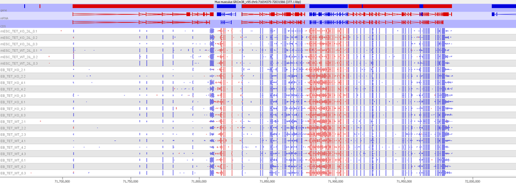

### RNA QC Plot

EB_TET_WT_4.2 with more rRNA than the others

percentage of exonic reads slightly higher for ESC (seems to be due to higher percentage of mitochondrial reads for EB)

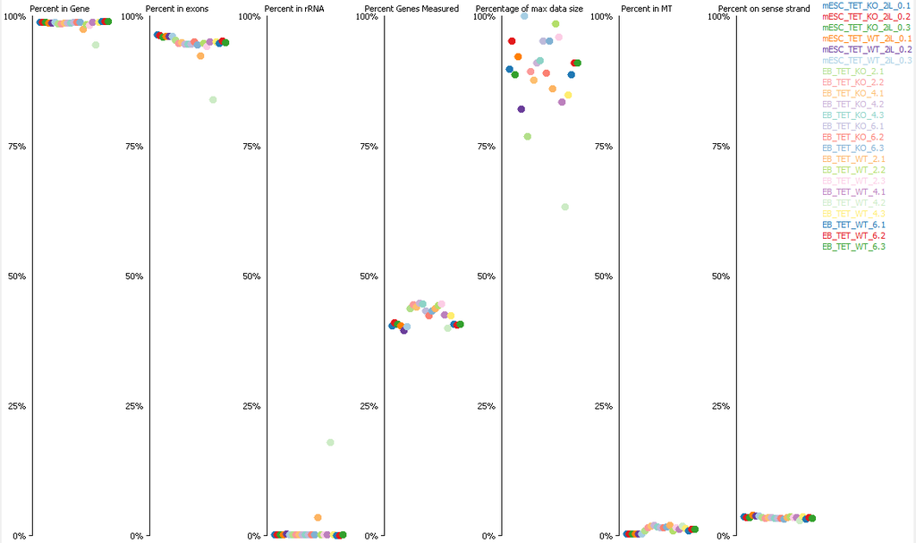

Replicate Set Created

ESC_TET_KO mESC_TET_KO_2iL_0.1 mESC_TET_KO_2iL_0.2 mESC_TET_KO_2iL_0.3

Replicate Set Created

ESC_TET_WT mESC_TET_WT_2iL_0.1 mESC_TET_WT_2iL_0.2 mESC_TET_WT_2iL_0.3

Replicate Set Created

EB_TET_KO_2 EB_TET_KO_2.1 EB_TET_KO_2.2

Replicate Set Created

EB_TET_KO_4 EB_TET_KO_4.1 EB_TET_KO_4.2 EB_TET_KO_4.3

Replicate Set Created

EB_TET_KO_6 EB_TET_KO_6.1 EB_TET_KO_6.2 EB_TET_KO_6.3

Replicate Set Created

EB_TET_WT_2 EB_TET_WT_2.1 EB_TET_WT_2.2 EB_TET_WT_2.3

Replicate Set Created

EB_TET_WT_4 EB_TET_WT_4.1 EB_TET_WT_4.2 EB_TET_WT_4.3

Replicate Set Created

EB_TET_WT_6 EB_TET_WT_6.1 EB_TET_WT_6.2 EB_TET_WT_6.3

New Probe Set:All Probes (54682 probes)

Feature generator using gene split into exons duplicates removed Over feature from 0-0

Probes Quantitated

Read Count Quantitation using All Reads correcting for total count per million reads log transformed

### Duplication

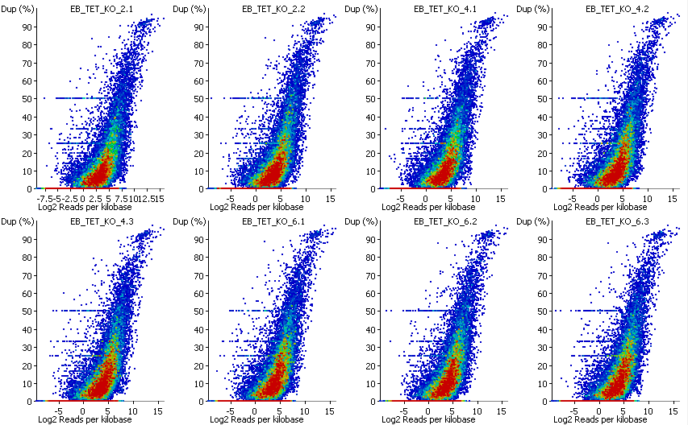

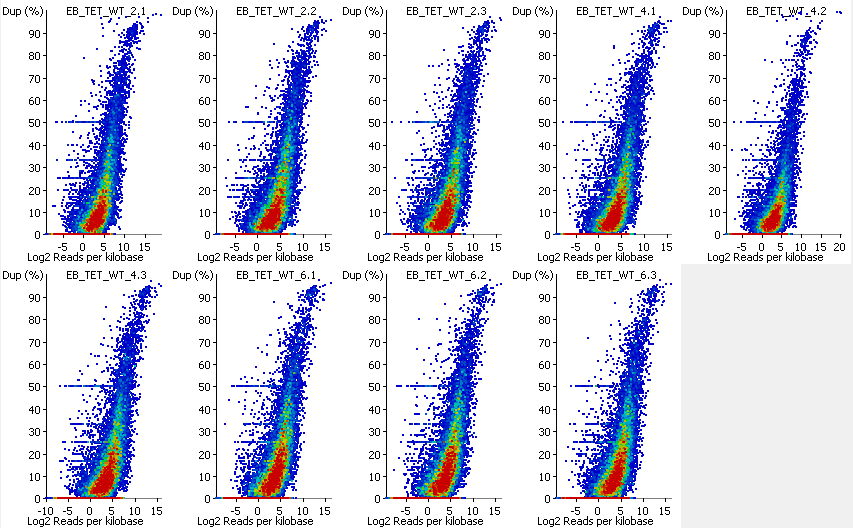

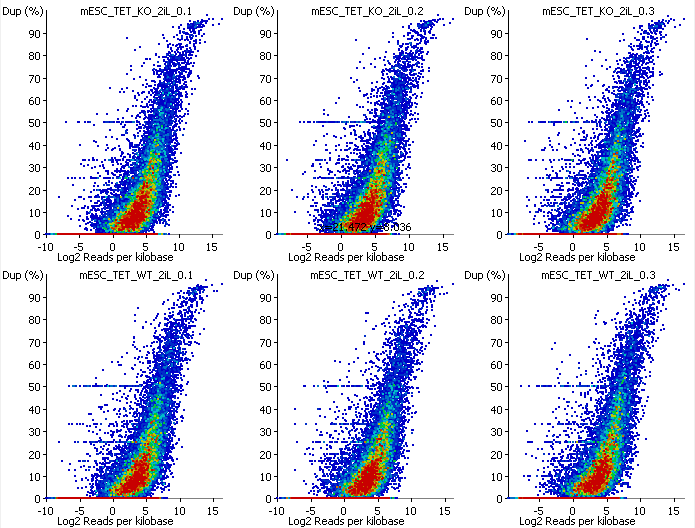

no issues with duplication

### Data store similarity

New Probe Set:All Probes (35266 probes)

Transcript features over mRNA

Probes Quantitated

RNA-Seq pipeline quantitation on merged transcripts counting reads over exons. Log transformed. Assuming a Opposing strand specific library

Probe List Renamed

Probe list All Probes renamed to mRNA

### Cumulative distributions

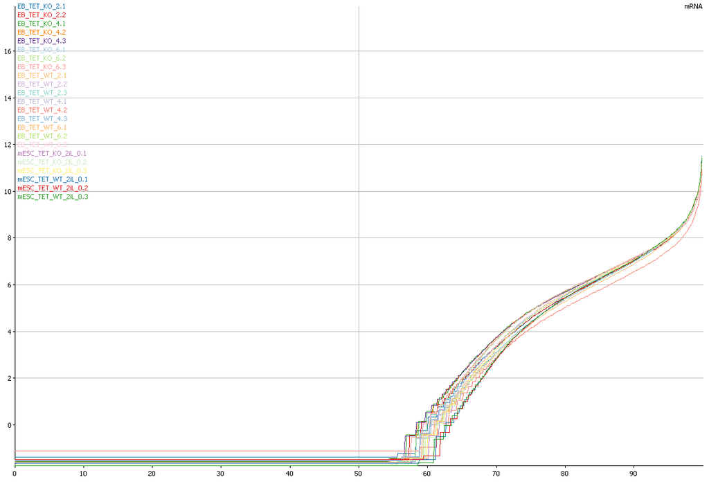

### Data Store Tree

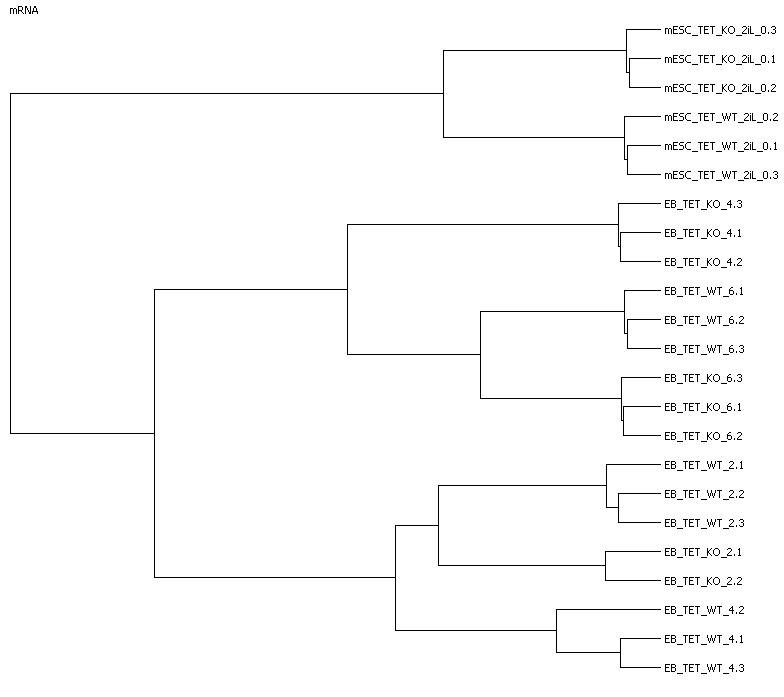

### PCA

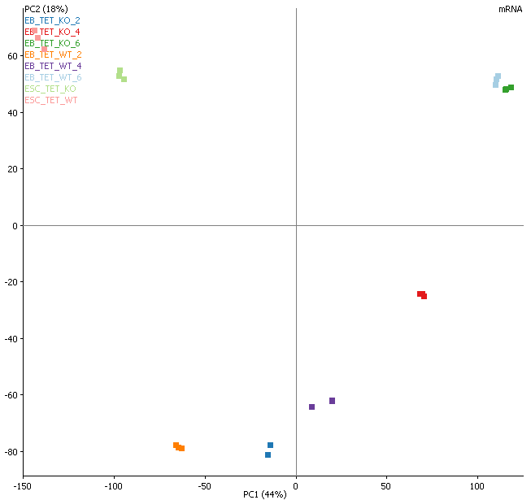

PC1 seems to be pretty much timepoint. KO seems to be a bit faster ...

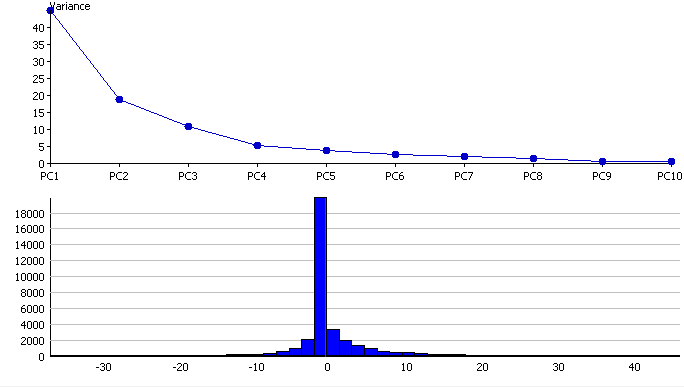

### Initial differential expression

New Probe List: Tets (3 probes)

[Probe Name Filter] Probes from mRNA whose name matches any of Tet1,Tet2,Tet3 after stripping probe generator suffixes

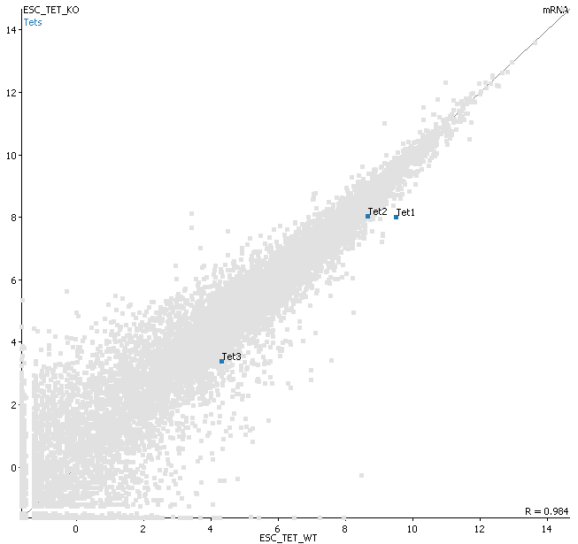

Overall data quality is looking good. There are some differences between TET WT and KO.

Double check KO strategy as mRNA levels aren't particularly different.